Charles Book Club Case Analysis

Hinako Samson

2

Charles Book Club Case Analysis

The Charles Book Club (CBC), established in December 1986, aimed to differentiate

itself by understanding its customer base and offering tailored products. Despite increasing

mailing volume and customer database size, CBC faced declining profits. To address this, they

planned to utilize database marketing to target profitable customers and design tailored

marketing strategies. In this scenario, CBC is attempting to send out mailings to gauge interest in

a book titled "The Art History of Florence" while minimizing costs by targeting only potential

buyers, highlighting the importance of effective targeting in maximizing profitability.

Analysis

Database marketing utilizes segmentation to group prospects into homogeneous segments

based on their buying behavior. The goal is to identify individuals with a high propensity to

purchase a particular offering. Since this propensity can't be directly measured, variables such as

R; recency (time since last purchase), F; frequency (number of previous purchases from the

company over a period), and M; monetary value (amount of money spent on the company’s

products over a period) are commonly used indicators. These variables, known as RFM

variables, help businesses effectively target potential customers in direct marketing campaigns.

Monetary Value vs. Frequency

First, I used ggplot() + geom_point() to see the correlation between monetary value

(amount spent) and frequency (number of previous purchases). Chart 1 below shows that the

monetary value and frequency have a positive correlation. Customers who shop more frequently

have spent more money in total.

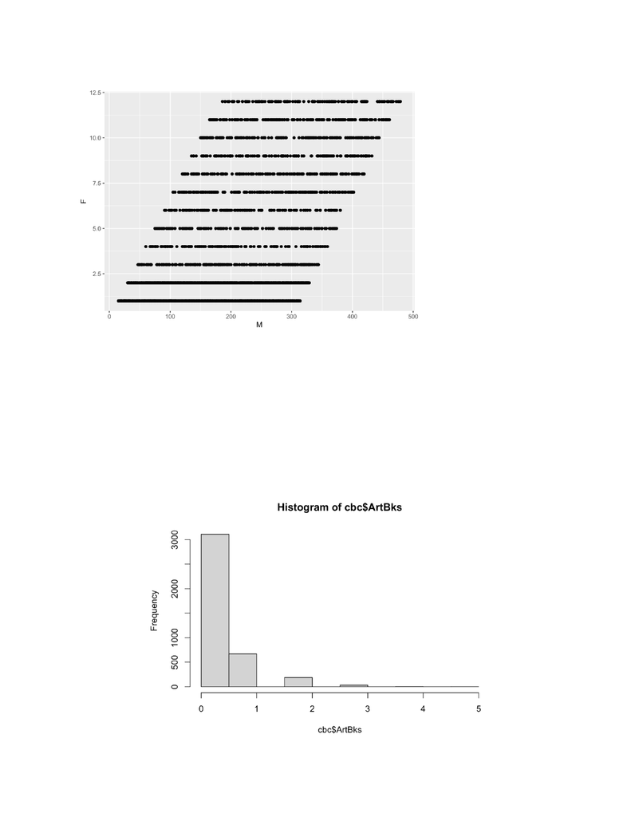

3

Chart 1

Art Books

The new book CBC is trying to sell is in the art category, so I used a histogram to analyze

how popular art books are. The number of frequencies that are between zero to one is

significantly higher than in other ranges, and this indicates that customers are not interested in art

books.

Chart 2

[figure not shown]

4

K-Nearest Neighbors

For this project, I have set the proportion of data to be used for training to 80%.

“Ypred_knn= knn” performs k-nearest neighbors’ classification on the training and validation

datasets using the variables “Rcode” and “Mcode” as predictors and "Gender" as the target

variable. With the “my.statistics” function with the actual gender values from the validation

dataset (data.val$Gender) and the predicted gender values (Ypred_knn), we returned the

classification metrics as shown in Table 1. This says the model correctly predicted "female" for

551 instances (TP: true positive) and that the model incorrectly predicted "female" for 249

instances (predicted "female" but was actually "male").

Table 1

## $confusion.table

## Predicted

## Actual 0 1

## 0 0 249

## 1 0 551

##

## $accuracy

## [1] 0.68875

##

## $precission

## [1] 0.68875

##

## $sensitivity

## [1] 1

##

## $specificity

## [1] 0

##

## $FPR

## [1] 1

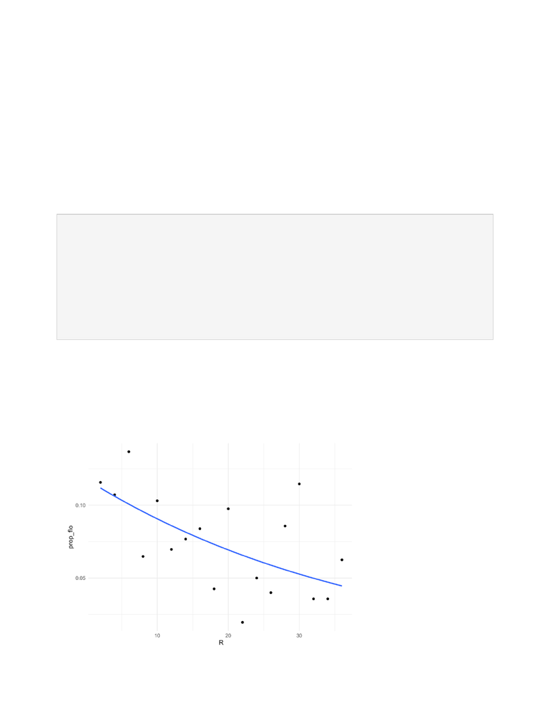

5

Logistic Regression

I created a logistic regression model using the code below. For logistic regression, we

have to use a binary variable. I wanted to analyze the logistic regression of recency (time since

last purchase) and whether customers purchased Art History of Florence which is categorized as

yes or no (binary). This code below creates a scatter plot of the data points with a smoothed

curve fitted using a generalized linear model assuming a binomial distribution.

ggplot(flo_sum, aes(x = R,

y = prop_flo,

weight = count)) +

geom_point() +

geom_smooth(method = "glm",

se = FALSE,

method.args = list(family = "binomial"))

Chart 3

6

Recommendations

Based on this brief case analysis of customer behavior, I recommend setting a focus on

customers who have purchased books many times and who have done that recently, especially

7

References

Shmueli, G., Bruce, P. C., Yahav, I., Patel, N. R. (Nitin R., & Lichtendahl, K. C. (2018). Data

mining for business analytics: concepts, techniques, and applications in R. John Wiley &

Sons, Inc.